### Scots Bay Survey #9 - 2026-08-30

This fishing survey will include 3 participating vessels.

Vessels will complete the following lines: All vessels will be running 2 lines in the Main Survey Box .

The Lady Janice will conduct plankton tows and oceanographic sampling.

The survey will have a start time of 20:00:00.

Vessels are reminded to complete their assigned transects as listed, straight, and without deviating.

**When running your transect, if you are recording a school of fish but are near the end of your line, please continue recording in a straight line even if it extends beyond the boundaries of the survey box.**

**Please wait until all vessels finish their lines before starting to fish.**

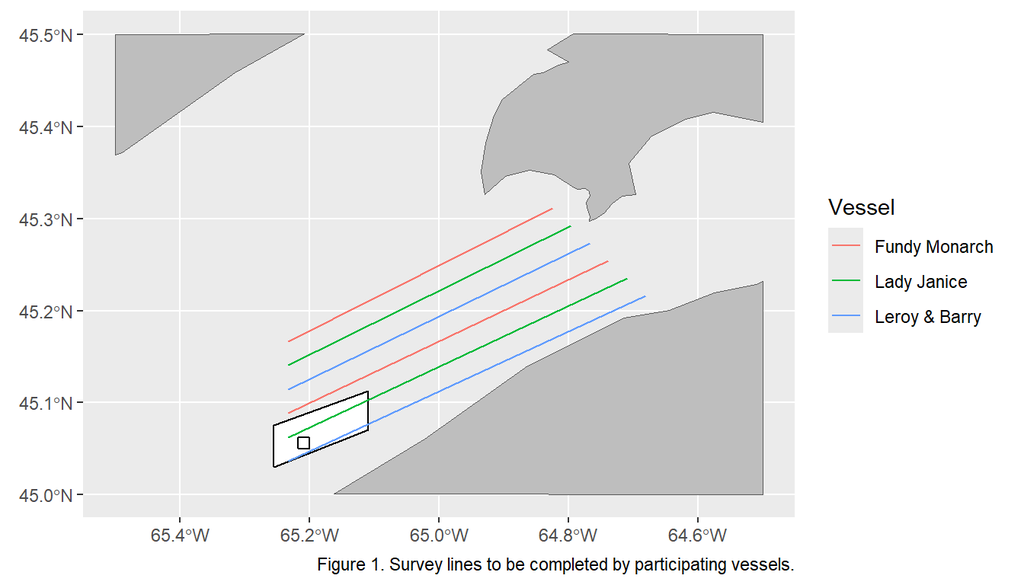

The Lady Janice will complete both plankton towing (bottom left outer box) and CTD casts (inner box) .

CTD Box

| Lat | Lon |
| --- | --- |
| 4503.432 | 6513.048 |
| 4503.000 | 6513.048 |
| 4503.000 | 6512.000 |
| 4503.432 | 6512.000 |

Tow Box

| Lat | Lon |
| --- | --- |
| 4501.80 | 6515.3 |
| 4504.20 | 6506.6 |
| 4506.78 | 6506.6 |
| 4504.50 | 6515.3 |

##### Full Lines Table

| Vessel | Start.Lat | Start.Lon | End.Lat | End.Lon |
| --- | --- | --- | --- | --- |
| Fundy Monarch | 4505.309 | 6514 | 4515.264 | 6444.318 |
| Fundy Monarch | 4510.000 | 6514 | 4518.700 | 6449.500 |
| Lady Janice | 4503.746 | 6514 | 4514.118 | 6442.591 |
| Lady Janice | 4508.436 | 6514 | 4517.555 | 6447.773 |
| Leroy & Barry | 4502.182 | 6514 | 4512.973 | 6440.864 |
| Leroy & Barry | 4506.873 | 6514 | 4516.409 | 6446.046 |

### Instructions

1. Plan to arrive at the starting point 30 minutes before the start time of 20:00:00.
2. Start the EK80 software and load the ‘Herring Survey 2026’ settings. When you are ready to begin, Record Raw should be turned ‘ON’ and the ‘REC’ dot in the upper left should turn from black to red. Finally, check that the lat and long in the top center of the screen is changing.
3. Commence surveying first line at 20:00:00 and maintain a speed at 8 knots.
4. Run your lines straight and double check that the recorder is turned on and red.
5. Maintain deck sheets as a backup to recorders every 15 minutes.
6. Note the time when finished your last line.
7. Fishing to start on 2026-08-31, and allocation is 200mt/vessel.Please wait until all vessels have completed their lines before starting to fish

### Tidal Charts

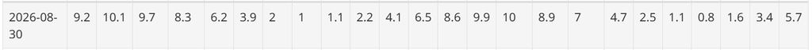

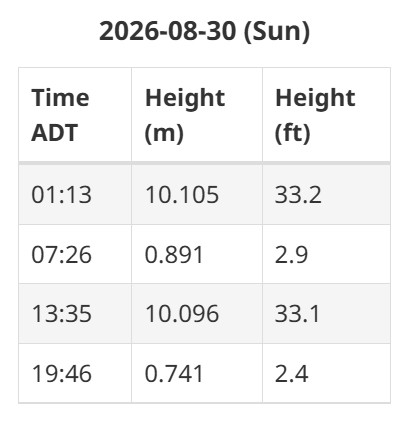